# Project - Write a Data Science Blog Post

In this project, I decided to look at what education or learning sources I should focus on in becoming a data scientist, and how these relate to compensation in the industry. I also explore what programming language I should learn first. To answer these questions, I have used [Kaggle's](https://www.kaggle.com/c/kaggle-survey-2019) yearly data science & machine learning survey for 2019 to find out what data scientists active in the industry have done and think.

To answer my questions in a structured format I will use the **CRISP-DM** process, which is a cross industry process for data mining:

1. Business Understanding 2. Data Understanding 3. Prepare Data 4. Data Modeling 5. Evaluate the Results 6. Deploy

## 1. Business Understanding

As an anspiring data scientist myself, I am interested in understanding what education or learning sources I should focus on to break into the industry, and how these relate to the compensations in the industry. I would also like to understand where my focus should be in terms of programming languages, and to explore this I have four questions I would like to answer:

**Business Questions:**

1. What education or learning platforms should I focus on in becoming a Data Scientist?
2. How do different education levels and learning platforms relate to compensation?
3. What programming language should I learn?
4. What biases might respondents have in recommending which programming language to learn?

## 2. Data Understanding

Below we see the survey methodology from Kaggle and two separate dataframes with all the questions and a survey schema that explains which respondents that have been excluded from certain questions.

**Survey Methodology from [Kaggle](https://www.kaggle.com/c/kaggle-survey-2019/data):**

- This survey received 19,717 usable respondents from 171 countries and territories. If a country or territory received less than 50 respondents, we grouped them into a group named “Other” for anonymity.
- We excluded respondents who were flagged by our survey system as “Spam”.
- Most of our respondents were found primarily through Kaggle channels, like our email list, discussion forums and social media channels.
- The survey was live from October 8th to October 28th. We allowed respondents to complete the survey at any time during that window. The median response time for those who participated in the survey was approximately 10 minutes.
- Not every question was shown to every respondent. You can learn more about the different segments we used in the survey_schema.csv file. In general, respondents with more experience were asked more questions and respondents with less experience were asked less questions.
- To protect the respondents’ identity, the answers to multiple choice questions have been separated into a separate data file from the open-ended responses. We do not provide a key to match up the multiple choice and free form responses. Further, the free form responses have been randomized column-wise such that the responses that appear on the same row did not necessarily come from the same survey-taker.
- Multiple choice single response questions fit into individual columns whereas multiple choice multiple response questions were split into multiple columns. Text responses were encoded to protect user privacy and countries with fewer than 50 respondents were grouped into the category "other".

```python
# import libraries
import pandas as pd
import numpy as np
import matplotlib.pyplot as plt
import matplotlib.colors as mcolors
from sklearn.model_selection import train_test_split
from sklearn import linear_model
from sklearn.linear_model import LinearRegression, ElasticNet
from sklearn.metrics import mean_squared_error, r2_score
from sklearn.model_selection import GridSearchCV
from sklearn.preprocessing import MinMaxScaler

%matplotlib inline
```

```python
# show non-truncated columns
pd.set_option('display.max_colwidth', -1)
```

```python
# load dataset
# read in first two rows as header, header=[0,1]
df = pd.read_csv('multiple_choice_responses.csv')
df.head(2)
```

|  | Time from Start to Finish (seconds) | Q1 | Q2 | Q2_OTHER_TEXT | Q3 | Q4 | Q5 | Q5_OTHER_TEXT | Q6 | Q7 | ... | Q34_Part_4 | Q34_Part_5 | Q34_Part_6 | Q34_Part_7 | Q34_Part_8 | Q34_Part_9 | Q34_Part_10 | Q34_Part_11 | Q34_Part_12 | Q34_OTHER_TEXT |
| --- | --- | --- | --- | --- | --- | --- | --- | --- | --- | --- | --- | --- | --- | --- | --- | --- | --- | --- | --- | --- | --- |
| 0 | Duration (in seconds) | What is your age (# years)? | What is your gender? - Selected Choice | What is your gender? - Prefer to self-describe - Text | In which country do you currently reside? | What is the highest level of formal education that you have attained or plan to attain within the next 2 years? | Select the title most similar to your current role (or most recent title if retired): - Selected Choice | Select the title most similar to your current role (or most recent title if retired): - Other - Text | What is the size of the company where you are employed? | Approximately how many individuals are responsible for data science workloads at your place of business? | ... | Which of the following relational database products do you use on a regular basis? (Select all that apply) - Selected Choice - Microsoft SQL Server | Which of the following relational database products do you use on a regular basis? (Select all that apply) - Selected Choice - Oracle Database | Which of the following relational database products do you use on a regular basis? (Select all that apply) - Selected Choice - Microsoft Access | Which of the following relational database products do you use on a regular basis? (Select all that apply) - Selected Choice - AWS Relational Database Service | Which of the following relational database products do you use on a regular basis? (Select all that apply) - Selected Choice - AWS DynamoDB | Which of the following relational database products do you use on a regular basis? (Select all that apply) - Selected Choice - Azure SQL Database | Which of the following relational database products do you use on a regular basis? (Select all that apply) - Selected Choice - Google Cloud SQL | Which of the following relational database products do you use on a regular basis? (Select all that apply) - Selected Choice - None | Which of the following relational database products do you use on a regular basis? (Select all that apply) - Selected Choice - Other | Which of the following relational database products do you use on a regular basis? (Select all that apply) - Other - Text |
| 1 | 510 | 22-24 | Male | -1 | France | Master’s degree | Software Engineer | -1 | 1000-9,999 employees | 0 | ... | NaN | NaN | NaN | NaN | NaN | NaN | NaN | NaN | NaN | -1 |

2 rows × 246 columns

```python
# drop row with question description, keep only question name
df = df.drop(0)
df
```

|  | Time from Start to Finish (seconds) | Q1 | Q2 | Q2_OTHER_TEXT | Q3 | Q4 | Q5 | Q5_OTHER_TEXT | Q6 | Q7 | ... | Q34_Part_4 | Q34_Part_5 | Q34_Part_6 | Q34_Part_7 | Q34_Part_8 | Q34_Part_9 | Q34_Part_10 | Q34_Part_11 | Q34_Part_12 | Q34_OTHER_TEXT |
| --- | --- | --- | --- | --- | --- | --- | --- | --- | --- | --- | --- | --- | --- | --- | --- | --- | --- | --- | --- | --- | --- |
| 1 | 510 | 22-24 | Male | -1 | France | Master’s degree | Software Engineer | -1 | 1000-9,999 employees | 0 | ... | NaN | NaN | NaN | NaN | NaN | NaN | NaN | NaN | NaN | -1 |
| 2 | 423 | 40-44 | Male | -1 | India | Professional degree | Software Engineer | -1 | > 10,000 employees | 20+ | ... | NaN | NaN | NaN | NaN | NaN | NaN | NaN | NaN | NaN | -1 |
| 3 | 83 | 55-59 | Female | -1 | Germany | Professional degree | NaN | -1 | NaN | NaN | ... | NaN | NaN | NaN | NaN | NaN | NaN | NaN | NaN | NaN | -1 |
| 4 | 391 | 40-44 | Male | -1 | Australia | Master’s degree | Other | 0 | > 10,000 employees | 20+ | ... | NaN | NaN | NaN | NaN | NaN | Azure SQL Database | NaN | NaN | NaN | -1 |
| 5 | 392 | 22-24 | Male | -1 | India | Bachelor’s degree | Other | 1 | 0-49 employees | 0 | ... | NaN | NaN | NaN | NaN | NaN | NaN | NaN | NaN | NaN | -1 |
| ... | ... | ... | ... | ... | ... | ... | ... | ... | ... | ... | ... | ... | ... | ... | ... | ... | ... | ... | ... | ... | ... |
| 19713 | 84 | 50-54 | Male | -1 | Japan | NaN | NaN | -1 | NaN | NaN | ... | NaN | NaN | NaN | NaN | NaN | NaN | NaN | NaN | NaN | -1 |
| 19714 | 473 | 18-21 | Male | -1 | India | Bachelor’s degree | Other | -1 | 250-999 employees | 3-4 | ... | NaN | NaN | NaN | NaN | NaN | NaN | NaN | NaN | NaN | -1 |
| 19715 | 9195 | 35-39 | Male | -1 | India | Master’s degree | Student | -1 | NaN | NaN | ... | NaN | NaN | NaN | NaN | NaN | NaN | NaN | NaN | NaN | -1 |
| 19716 | 176 | 25-29 | Male | -1 | India | Master’s degree | Statistician | -1 | 50-249 employees | 15-19 | ... | NaN | NaN | NaN | NaN | NaN | NaN | NaN | NaN | NaN | -1 |
| 19717 | 567 | 50-54 | Male | -1 | France | Bachelor’s degree | Software Engineer | -1 | > 10,000 employees | 20+ | ... | NaN | NaN | NaN | NaN | NaN | NaN | NaN | NaN | NaN | -1 |

19717 rows × 246 columns

```python
# load questions
questions = pd.read_csv('questions_only.csv')
questions.transpose()
```

|  | 0 |
| --- | --- |
| Time from Start to Finish (seconds) | Duration (in seconds) |
| Q1 | What is your age (# years)? |
| Q2 | What is your gender? - Selected Choice |
| Q3 | In which country do you currently reside? |
| Q4 | What is the highest level of formal education that you have attained or plan to attain within the next 2 years? |
| Q5 | Select the title most similar to your current role (or most recent title if retired): - Selected Choice |
| Q6 | What is the size of the company where you are employed? |
| Q7 | Approximately how many individuals are responsible for data science workloads at your place of business? |
| Q8 | Does your current employer incorporate machine learning methods into their business? |
| Q9 | Select any activities that make up an important part of your role at work: (Select all that apply) - Selected Choice |
| Q10 | What is your current yearly compensation (approximate $USD)? |
| Q11 | Approximately how much money have you spent on machine learning and/or cloud computing products at your work in the past 5 years? |
| Q12 | Who/what are your favorite media sources that report on data science topics? (Select all that apply) - Selected Choice |
| Q13 | On which platforms have you begun or completed data science courses? (Select all that apply) - Selected Choice |
| Q14 | What is the primary tool that you use at work or school to analyze data? (Include text response) - Selected Choice |
| Q15 | How long have you been writing code to analyze data (at work or at school)? |
| Q16 | Which of the following integrated development environments (IDE's) do you use on a regular basis? (Select all that apply) - Selected Choice |
| Q17 | Which of the following hosted notebook products do you use on a regular basis? (Select all that apply) - Selected Choice |
| Q18 | What programming languages do you use on a regular basis? (Select all that apply) - Selected Choice |
| Q19 | What programming language would you recommend an aspiring data scientist to learn first? - Selected Choice |
| Q20 | What data visualization libraries or tools do you use on a regular basis? (Select all that apply) - Selected Choice |
| Q21 | Which types of specialized hardware do you use on a regular basis? (Select all that apply) - Selected Choice |
| Q22 | Have you ever used a TPU (tensor processing unit)? |
| Q23 | For how many years have you used machine learning methods? |
| Q24 | Which of the following ML algorithms do you use on a regular basis? (Select all that apply): - Selected Choice |
| Q25 | Which categories of ML tools do you use on a regular basis? (Select all that apply) - Selected Choice |
| Q26 | Which categories of computer vision methods do you use on a regular basis? (Select all that apply) - Selected Choice |
| Q27 | Which of the following natural language processing (NLP) methods do you use on a regular basis? (Select all that apply) - Selected Choice |
| Q28 | Which of the following machine learning frameworks do you use on a regular basis? (Select all that apply) - Selected Choice |
| Q29 | Which of the following cloud computing platforms do you use on a regular basis? (Select all that apply) - Selected Choice |
| Q30 | Which specific cloud computing products do you use on a regular basis? (Select all that apply) - Selected Choice |
| Q31 | Which specific big data / analytics products do you use on a regular basis? (Select all that apply) - Selected Choice |
| Q32 | Which of the following machine learning products do you use on a regular basis? (Select all that apply) - Selected Choice |
| Q33 | Which automated machine learning tools (or partial AutoML tools) do you use on a regular basis? (Select all that apply) - Selected Choice |
| Q34 | Which of the following relational database products do you use on a regular basis? (Select all that apply) - Selected Choice |

**Here we can more easily read which questions are included in the dataset.**

```python
# load questions, show all columns
survey_schema = pd.read_csv('survey_schema.csv')

with pd.option_context('display.max_columns', 250):
    display(survey_schema)
```

|  | 2019 Kaggle Machine Learning and Data Science Survey | Q1 | Q10 | Q11 | Q12 | Q13 | Q14 | Q15 | Q16 | Q17 | Q18 | Q19 | Q2 | Q20 | Q21 | Q22 | Q23 | Q24 | Q25 | Q26 | Q27 | Q28 | Q29 | Q3 | Q30 | Q31 | Q32 | Q33 | Q34 | … |
| --- | --- | --- | --- | --- | --- | --- | --- | --- | --- | --- | --- | --- | --- | --- | --- | --- | --- | --- | --- | --- | --- | --- | --- | --- | --- | --- | --- | --- | --- | --- |
| 0 | Question: | What is your age (# years)? | What is your current yearly compensation (approximate $USD)? | Approximately how much money have you spent on machine learning and/or cloud computing products at your work in the past 5 years? | Who/what are your favorite media sources that report on data science topics? (Select all that apply) - Selected Choice | On which platforms have you begun or completed data science courses? (Select all that apply) - Selected Choice | What is the primary tool that you use at work or school to analyze data? (Include text response) - Selected Choice | How long have you been writing code to analyze data (at work or at school)? | Which of the following integrated development environments (IDE's) do you use on a regular basis? (Select all that apply) - Selected Choice | Which of the following hosted notebook products do you use on a regular basis? (Select all that apply) - Selected Choice | What programming languages do you use on a regular basis? (Select all that apply) - Selected Choice | What programming language would you recommend an aspiring data scientist to learn first? - Selected Choice | What is your gender? - Selected Choice | What data visualization libraries or tools do you use on a regular basis? (Select all that apply) - Selected Choice | Which types of specialized hardware do you use on a regular basis? (Select all that apply) - Selected Choice | Have you ever used a TPU (tensor processing unit)? | For how many years have you used machine learning methods? | Which of the following ML algorithms do you use on a regular basis? (Select all that apply): - Selected Choice | Which categories of ML tools do you use on a regular basis? (Select all that apply) - Selected Choice | Which categories of computer vision methods do you use on a regular basis? (Select all that apply) - Selected Choice | Which of the following natural language processing (NLP) methods do you use on a regular basis? (Select all that apply) - Selected Choice | Which of the following machine learning frameworks do you use on a regular basis? (Select all that apply) - Selected Choice | Which of the following cloud computing platforms do you use on a regular basis? (Select all that apply) - Selected Choice | In which country do you currently reside? | Which specific cloud computing products do you use on a regular basis? (Select all that apply) - Selected Choice | Which specific big data / analytics products do you use on a regular basis? (Select all that apply) - Selected Choice | Which of the following machine learning products do you use on a regular basis? (Select all that apply) - Selected Choice | Which automated machine learning tools (or partial AutoML tools) do you use on a regular basis? (Select all that apply) - Selected Choice | Which of the following relational database products do you use on a regular basis? (Select all that apply) - Selected Choice | … |
| 1 | # of Respondents: | 19717 | 12497 | 12250 | 16781 | 16569 | 15690 | 15627 | 14627 | 14443 | 14404 | 14377 | 19717 | 14253 | 14218 | 14203 | 14182 | 14088 | 13915 | 5492 | 3582 | 13753 | 7125 | 19717 | 7100 | 7078 | 7050 | 7015 | 6994 | … |
| 2 | Who was excluded? (0 = not excluded; 1 = excluded) | 0 | 0 | 0 | 0 | 0 | 0 | 0 | 0 | 0 | 0 | 0 | 0 | 0 | 0 | 0 | 0 | 0 | 0 | 0 | 0 | 0 | 0 | 0 | 0 | 0 | 0 | 0 | 0 | … |
| 3 | If What is your age (# years)? 0-17 Is Selected | 0 | 1 | 1 | 1 | 1 | 1 | 1 | 1 | 1 | 1 | 1 | 1 | 1 | 1 | 1 | 1 | 1 | 1 | 1 | 1 | 1 | 1 | 1 | 1 | 1 | 1 | 1 | 1 | … |
| 4 | If Select the title most similar to your current role (or most recent title if retired): Student Is Selected OR Select the title most similar to your current role (or most recent title if retired): No… | 0 | 1 | 1 | 0 | 0 | 0 | 0 | 0 | 0 | 0 | 0 | 0 | 0 | 0 | 0 | 0 | 0 | 0 | 0 | 0 | 0 | 0 | 0 | 0 | 0 | 0 | 0 | 0 | … |
| 5 | If How long have you been writing code to analyze data (at work or at school)? I have never written code Is Selected | 0 | 0 | 0 | 0 | 0 | 0 | 0 | 1 | 1 | 1 | 1 | 0 | 1 | 1 | 1 | 1 | 1 | 1 | 1 | 1 | 1 | 1 | 0 | 1 | 1 | 1 | 1 | 1 | … |
| 6 | If Approximately how much money have you spent on machine learning and/or cloud computing products a... $0 (USD) Is Selected | 0 | 0 | 0 | 0 | 0 | 0 | 0 | 0 | 0 | 0 | 0 | 0 | 0 | 0 | 0 | 0 | 0 | 0 | 0 | 0 | 0 | 1 | 0 | 1 | 1 | 1 | 1 | 1 | … |
| 7 | If Which of the following ML algorithms do you use on a regular basis? (Select all that apply): Convolutional Neural Networks Is Not Selected Or Which of the following ML algorithms do you use on a re… | 0 | 0 | 0 | 0 | 0 | 0 | 0 | 0 | 0 | 0 | 0 | 0 | 0 | 0 | 0 | 0 | 0 | 0 | 1 | 0 | 0 | 0 | 0 | 0 | 0 | 0 | 0 | 0 | … |
| 8 | If Which of the following ML algorithms do you use on a regular basis? (Select all that apply): Recurrent Neural Networks Is Not Selected Or Which of the following ML algorithms do you use on a regula… | 0 | 0 | 0 | 0 | 0 | 0 | 0 | 0 | 0 | 0 | 0 | 0 | 0 | 0 | 0 | 0 | 0 | 0 | 0 | 1 | 0 | 0 | 0 | 0 | 0 | 0 | 0 | 0 | … |
| 9 | If Does your current employer incorporate machine learning methods into their business? No (we do not use ML methods) Is Selected Or Does your current employer incorporate machine learning methods int… | 0 | 0 | 0 | 0 | 0 | 0 | 0 | 0 | 0 | 0 | 0 | 0 | 0 | 0 | 0 | 0 | 0 | 0 | 0 | 0 | 0 | 0 | 0 | 0 | 0 | 0 | 0 | 0 | … |

**Here we can see the survey schema with the total number of respondents per questions and who what excluded from certain questions. For example, we can see that respondent aged 0-17 years old are excluded from many questions.**

```python
df.shape
```

```
(19717, 246)
```

```python
df.info()
```

```
<class 'pandas.core.frame.DataFrame'>
Int64Index: 19717 entries, 1 to 19717
Columns: 246 entries, Time from Start to Finish (seconds) to Q34_OTHER_TEXT
dtypes: object(246)
memory usage: 37.2+ MB
```

**The dataset has 19 717 rows and 246 columns.**

```python
# count missing values (NaNs) in dataframe
df.isnull().sum().sum()
```

```
3594883
```

```python
# count empty strings in dataframe
(df == '').sum().sum()
```

```
0
```

**There are 3 594 883 missing values in the dataframe but no empty strings.**

```python
df['Q5'].value_counts()
```

```
Data Scientist             4085
Student                    4014
Software Engineer          2705
Other                      1690
Data Analyst               1598
Research Scientist         1470
Not employed               942
Business Analyst           778
Product/Project Manager    723
Data Engineer              624
Statistician               322
DBA/Database Engineer      156
Name: Q5, dtype: int64
```

**The respondents in the survey data have different positions. We are interested in looking at data scientists active in the industry.**

```python
# explore a question set that has a '_TEXT' option (free text response)
df[['Q14',
    'Q14_Part_1_TEXT',
    'Q14_Part_2_TEXT',
    'Q14_Part_3_TEXT',
    'Q14_Part_4_TEXT',
    'Q14_Part_5_TEXT',
    'Q14_OTHER_TEXT']]
```

|  | Q14 | Q14_Part_1_TEXT | Q14_Part_2_TEXT | Q14_Part_3_TEXT | Q14_Part_4_TEXT | Q14_Part_5_TEXT | Q14_OTHER_TEXT |
| --- | --- | --- | --- | --- | --- | --- | --- |
| 1 | Basic statistical software (Microsoft Excel, Google Sheets, etc.) | 0 | -1 | -1 | -1 | -1 | -1 |
| 2 | Cloud-based data software & APIs (AWS, GCP, Azure, etc.) | -1 | -1 | -1 | -1 | 0 | -1 |
| 3 | NaN | -1 | -1 | -1 | -1 | -1 | -1 |
| 4 | Local development environments (RStudio, JupyterLab, etc.) | -1 | -1 | -1 | 0 | -1 | -1 |
| 5 | Local development environments (RStudio, JupyterLab, etc.) | -1 | -1 | -1 | 1 | -1 | -1 |
| ... | ... | ... | ... | ... | ... | ... | ... |
| 19713 | NaN | -1 | -1 | -1 | -1 | -1 | -1 |
| 19714 | Local development environments (RStudio, JupyterLab, etc.) | -1 | -1 | -1 | 28 | -1 | -1 |
| 19715 | NaN | -1 | -1 | -1 | -1 | -1 | -1 |
| 19716 | NaN | -1 | -1 | -1 | -1 | -1 | -1 |
| 19717 | Local development environments (RStudio, JupyterLab, etc.) | -1 | -1 | -1 | 25 | -1 | -1 |

19717 rows × 7 columns

```python
df['Q14_Part_1_TEXT'].value_counts()
```

```
-1     13346
-1     3311
1      636
0      283
1      229
      ...
822    1
821    1
820    1
203    1
673    1
Name: Q14_Part_1_TEXT, Length: 1015, dtype: int64
```

**As we can see from exploing a question that contains free text, there is no response. In the survey methodology we can read that the text responses have been removed to ensure privacy, and they are no longer linked to a respondent, so we will not use these in our analysis.**

## 3. Prepare Data

In order to prepare our data for modelling, we need to:

- remove columns with text responses, they have no response in them
- only keep survey data where the respondent is active as a data scientist in the industry
- recode our target variable ‘yearly compensation in USD’ (Q10) into one that can be used in modelling. We will make it numerical and ordinal based on the compensation brackets
- recode one of our input features ‘on which platforms respondents have begun or completed data science courses’ (Q13) into a format that can be used in modeling. We will rename each column header to represent the platform referred to, and make them numerical binary columns
- one hot encode categorical input feature ‘highest level of education attained or planned to attain within 2 years’ (Q4) to make it into numerical binary columns per category option that can be used in modelling
- split our data it into training and test sets to use to train and test our models
- create a new dataframe with percentage of respondents that recommend to learn a programming language and use it themselves regularly, the percentage of respondents who recommend it but don’t use it and the difference between these groups. To do this, we need to create new columns where respondents are recommending the programming language in Q19 and stated that they use it on a regular basis in Q18, and respondents that recommend it in Q19 but not stated that they use it in Q18

```python
def clean_data(df):
    '''
    Function that:
    - removes columns with text responses from dataframe
    - only keeps rows where the respondents occupation is 'data scientist'

    INPUT:
    df (pandas dataframe)

    OUTPUT:
    df (pandas dataframe) - excluding columns with text resonses and
    '''
    # remove questions with free text responses
    df = df.drop(columns=['Q2_OTHER_TEXT',
                          'Q5_OTHER_TEXT',
                          'Q9_OTHER_TEXT',
                          'Q12_OTHER_TEXT',
                          'Q13_OTHER_TEXT',
                          'Q14_Part_1_TEXT',
                          'Q14_Part_2_TEXT',
                          'Q14_Part_3_TEXT',
                          'Q14_Part_4_TEXT',
                          'Q14_Part_5_TEXT',
                          'Q14_OTHER_TEXT',
                          'Q16_OTHER_TEXT',
                          'Q17_OTHER_TEXT',
                          'Q18_OTHER_TEXT',
                          'Q19_OTHER_TEXT',
                          'Q20_OTHER_TEXT',
                          'Q21_OTHER_TEXT',
                          'Q24_OTHER_TEXT',
                          'Q25_OTHER_TEXT',
                          'Q26_OTHER_TEXT',
                          'Q27_OTHER_TEXT',
                          'Q28_OTHER_TEXT',
                          'Q29_OTHER_TEXT',
                          'Q30_OTHER_TEXT',
                          'Q31_OTHER_TEXT',
                          'Q32_OTHER_TEXT',
                          'Q33_OTHER_TEXT',
                          'Q34_OTHER_TEXT'])

    # only keep respondents that work as data scientists in the dataset
    df = df[df['Q5'] == 'Data Scientist']

    return df
```

```python
df = clean_data(df)
```

```python
# check that free text columns have been removed
df.columns.tolist()
```

```
['Time from Start to Finish (seconds)',
 'Q1',
 'Q2',
 'Q3',
 'Q4',
 'Q5',
 'Q6',
 'Q7',
 'Q8',
 'Q9_Part_1',
 'Q9_Part_2',
 'Q9_Part_3',
 'Q9_Part_4',
 'Q9_Part_5',
 'Q9_Part_6',
 'Q9_Part_7',
 'Q9_Part_8',
 'Q10',
 'Q11',
 'Q12_Part_1',
 'Q12_Part_2',
 'Q12_Part_3',
 'Q12_Part_4',
 'Q12_Part_5',
 'Q12_Part_6',
 'Q12_Part_7',
 'Q12_Part_8',
 'Q12_Part_9',
 'Q12_Part_10',
 'Q12_Part_11',
 'Q12_Part_12',
 'Q13_Part_1',
 'Q13_Part_2',
 'Q13_Part_3',
 'Q13_Part_4',
 'Q13_Part_5',
 'Q13_Part_6',
 'Q13_Part_7',
 'Q13_Part_8',
 'Q13_Part_9',
```

[output cut: 163 more lines]

```
 'Q33_Part_10',
 'Q33_Part_11',
 'Q33_Part_12',
 'Q34_Part_1',
 'Q34_Part_2',
 'Q34_Part_3',
 'Q34_Part_4',
 'Q34_Part_5',
 'Q34_Part_6',
 'Q34_Part_7',
 'Q34_Part_8',
 'Q34_Part_9',
 'Q34_Part_10',
 'Q34_Part_11',
 'Q34_Part_12']
```

**We have removed all columns indicating they're related to a text resonse.**

```python
df['Q5'].value_counts()
```

```
Data Scientist    4085
Name: Q5, dtype: int64
```

```python
df.shape
```

```
(4085, 218)
```

**In this analysis, we are interested in respondents working as Data Scientists, so we will only keep samples in the dataset where the respone to 'Q5. Select the title most similar to your current role (or most recent title if retired)' is 'Data Scientist'.**

```python
def add_columns(df):
    '''
    Function that:
    - creates new column 'comp', recoded as a numerical ordinal column based on values in 'Q10', with
      increasing order from lowest to highest compensation range
    - creates new columns per learning platform option from 'Q13', and recodes these into binary columns
    - one hot encodes categorical column 'Q4', creating binary dummy variables per column value

    INPUT:
    df (pandas dataframe)

    OUTPUT:
    df (pandas dataframe), with new columns:
        - 'comp': column 'Q10' recoded as a numerical ordinal column with increasing order from lowest to
          highest compensation range
        - numerical binary columns per learning platform option from 'Q13':
            - 'Udacity'
            - 'Coursera'
            - 'edX'
            - 'DataCamp'
            - 'DataQuest'
            - 'Kaggle Courses'
            - 'Fast.ai'
            - 'Udemy'
            - 'LinkedIn Learning'
            - 'University Courses'
            - 'None'
            - 'Other'
        - one hot encoded columns per value in 'Q4', making them binary columns:
            - 'Bachelor’s degree',
            - 'Doctoral degree',
            - 'I prefer not to answer',
            - 'Master’s degree',
            - 'No formal education past high school',
            - 'Professional degree',
            - 'Some college/university study without earning a bachelor’s degree'

    df_ml (pandas dataframe) - copy of 'df' but with removed rows where column 'comp' had missing values
    '''
    # create new column with copy of 'Q10'
    df['comp'] = df['Q10']

    # make our target variable 'comp' ordinal by replacing values with integers in increasing order form
    # lowest to highest compensation range
    df['comp'] = df['comp'].replace({'$0-999': 1,
                                     '1,000-1,999': 2,
                                     '2,000-2,999': 3,
                                     '3,000-3,999': 4,
                                     '4,000-4,999': 5,
                                     '5,000-7,499': 6,
                                     '7,500-9,999': 7,
                                     '10,000-14,999': 8,
                                     '15,000-19,999': 9,
                                     '20,000-24,999': 10,
                                     '25,000-29,999': 11,
                                     '30,000-39,999': 12,
                                     '40,000-49,999': 13,
                                     '50,000-59,999': 14,
                                     '60,000-69,999': 15,
                                     '70,000-79,999': 16,
                                     '80,000-89,999': 17,
                                     '90,000-99,999': 18,
                                     '100,000-124,999': 19,
                                     '125,000-149,999': 20,
                                     '150,000-199,999': 21,
                                     '200,000-249,999': 22,
                                     '250,000-299,999': 23,
                                     '300,000-500,000': 24,
                                     '> $500,000': 25})

    # create new columns by copying Q13 questions and renaming them to related learning platform options
    df['Udacity'] = df['Q13_Part_1']
    df['Coursera'] = df['Q13_Part_2']
    df['edX'] = df['Q13_Part_3']
    df['DataCamp'] = df['Q13_Part_4']
    df['DataQuest'] = df['Q13_Part_5']
    df['Kaggle Courses'] = df['Q13_Part_6']
    df['Fast.ai'] = df['Q13_Part_7']
    df['Udemy'] = df['Q13_Part_8']
    df['LinkedIn Learning'] = df['Q13_Part_9']
    df['University Courses'] = df['Q13_Part_10']
    df['None'] = df['Q13_Part_11']
    df['Other'] = df['Q13_Part_12']

    # replace values in new Q13 columns with 1 for value and 0 for NaN, making them numerical binary columns
    # source: https://stackoverflow.com/questions/37543647/how-to-replace-all-non-nan-entries-of-a-dataframe-
    # with-1-and-all-nan-with-0
    df['Udacity'] = (df['Udacity'].notnull()).astype('int')
    df['Coursera'] = (df['Coursera'].notnull()).astype('int')
    df['edX'] = (df['edX'].notnull()).astype('int')
    df['DataCamp'] = (df['DataCamp'].notnull()).astype('int')
    df['DataQuest'] = (df['DataQuest'].notnull()).astype('int')
    df['Kaggle Courses'] = (df['Kaggle Courses'].notnull()).astype('int')
    df['Fast.ai'] = (df['Fast.ai'].notnull()).astype('int')
    df['Udemy'] = (df['Udemy'].notnull()).astype('int')
    df['LinkedIn Learning'] = (df['LinkedIn Learning'].notnull()).astype('int')
    df['University Courses'] = (df['University Courses'].notnull()).astype('int')
    df['None'] = (df['None'].notnull()).astype('int')
    df['Other'] = (df['Other'].notnull()).astype('int')

    # one hot encode categorical column 'Q4', creating binary dummy variables per column value
    df_dummies = pd.get_dummies(df['Q4'])

    # merge 'df' and 'df_dummies' on index of both the dataframes
    df = df.merge(df_dummies, how='left', left_index=True, right_index=True)

    # create new dataframe for modeling and drop rows with missing data in column 'comp'
    df_ml = df.dropna(subset=['comp'])

    return df, df_ml
```

```python
df, df_ml = add_columns(df)
```

```python
df['Q10'].value_counts()
```

```
$0-999             379
100,000-124,999    269
40,000-49,999      237
10,000-14,999      220
30,000-39,999      220
50,000-59,999      206
125,000-149,999    204
150,000-199,999    201
60,000-69,999      175
70,000-79,999      169
1,000-1,999        151
20,000-24,999      144
25,000-29,999      138
90,000-99,999      131
15,000-19,999      122
80,000-89,999      121
7,500-9,999        108
5,000-7,499        105
2,000-2,999        95
3,000-3,999        65
200,000-249,999    59
4,000-4,999        53
250,000-299,999    26
> $500,000         22
300,000-500,000    20
Name: Q10, dtype: int64
```

```python
df['Q10'].describe()
```

```
count     3640
unique    25
top       $0-999
freq      379
Name: Q10, dtype: object
```

```python
df['Q10'].isna().sum()
```

```
445
```

**I have coded the yearly compensation question ('Q10') into a new column that I will recode so that we can use it to answer question 2. As we can see above, the current column values for Q10 are strings in an unordered format, and there are 445 missing values in the column.**

```python
df['comp'].value_counts().sort_index()
```

```
1.0     379
2.0     151
3.0     95
4.0     65
5.0     53
6.0     105
7.0     108
8.0     220
9.0     122
10.0    144
11.0    138
12.0    220
13.0    237
14.0    206
15.0    175
16.0    169
17.0    121
18.0    131
19.0    269
20.0    204
21.0    201
22.0    59
23.0    26
24.0    20
25.0    22
Name: comp, dtype: int64
```

**I have recoded the target variable 'Q10. What is your current yearly compensation (approximate $USD)?' into a numerical ordinal column by assigning integer values to each compensation range in ascending order, starting from the lowest to the highest compensation range. This allows us to keep a sense of order amongst the values when we use this column as our target variable, as opposed to simply recoding them into separate (nominal) categories. This means we have a regression problem at hand.**

```python
df.head(5)
```

|  | Time from Start to Finish (seconds) | Q1 | Q2 | Q3 | Q4 | Q5 | Q6 | Q7 | Q8 | Q9_Part_1 | ... | University Courses | None | Other | Bachelor’s degree | Doctoral degree | I prefer not to answer | Master’s degree | No formal education past high school | Professional degree | Some college/university study without earning a bachelor’s degree |
| --- | --- | --- | --- | --- | --- | --- | --- | --- | --- | --- | --- | --- | --- | --- | --- | --- | --- | --- | --- | --- | --- |
| 6 | 470 | 50-54 | Male | France | Master’s degree | Data Scientist | 0-49 employees | 3-4 | We have well established ML methods (i.e., models in production for more than 2 years) | NaN | ... | 0 | 1 | 0 | 0 | 0 | 0 | 1 | 0 | 0 | 0 |
| 7 | 529 | 22-24 | Male | India | Master’s degree | Data Scientist | 50-249 employees | 20+ | We are exploring ML methods (and may one day put a model into production) | Analyze and understand data to influence product or business decisions | ... | 0 | 0 | 0 | 0 | 0 | 0 | 1 | 0 | 0 | 0 |
| 8 | 624 | 22-24 | Female | United States of America | Bachelor’s degree | Data Scientist | > 10,000 employees | 20+ | We recently started using ML methods (i.e., models in production for less than 2 years) | Analyze and understand data to influence product or business decisions | ... | 1 | 0 | 0 | 1 | 0 | 0 | 0 | 0 | 0 | 0 |
| 13 | 397 | 30-34 | Male | Germany | Bachelor’s degree | Data Scientist | 50-249 employees | 5-9 | We recently started using ML methods (i.e., models in production for less than 2 years) | Analyze and understand data to influence product or business decisions | ... | 0 | 0 | 0 | 1 | 0 | 0 | 0 | 0 | 0 | 0 |
| 32 | 538 | 30-34 | Male | Japan | Master’s degree | Data Scientist | 0-49 employees | 10-14 | We are exploring ML methods (and may one day put a model into production) | Analyze and understand data to influence product or business decisions | ... | 0 | 0 | 0 | 0 | 0 | 0 | 1 | 0 | 0 | 0 |

5 rows × 238 columns

**I have created new columns for each learning platform with the platform name as the column name and recoded the columns into numerical binary ones where 1 represents if the learning platform was selected and 0 represents the NaNs. This is to prepare the columns to be used in the modeling, machine learning models can't deal with categorical variables otherwise and also not with missing data in features.**

**Above we have also recoded the education levels into separate numerical binary columns, called one-hot encoding, which gives the columns the same format as for the learning platforms.**

```python
df_ml.shape
```

```
(3640, 238)
```

```python
df_ml['comp'].isna().sum()
```

```
0
```

**We could see earlier that there was data missing in the yearly compensation column, and in the modeling dataset we have removed these rows.**

**There are no missing values in the modeling dataset and we're ready to use it.**

```python
def prepare_mldata(df_ml):
    '''
    Function that:
    - prepares data for modeling by:
        - setting up input features as 'X' and the target variable as 'y'
        - splitting data into train and test sets

    INPUT:
    df_ml (pandas dataframe)

    OUTPUT:
    'X' - inout features
    'y' - target variable
    'X_train' - train set
    'X_test' - test set
    'y_train' - train set
    'y_test' - test set
    '''
    # set up input features as 'X' and our target variable as 'y'
    X = df_ml[['Udacity',
               'Coursera',
               'edX',
               'DataCamp',
               'DataQuest',
               'Kaggle Courses',
               'Fast.ai',
               'Udemy',
               'LinkedIn Learning',
               'University Courses',
               'None',
               'Other',
               'Bachelor’s degree',
               'Doctoral degree',
               'I prefer not to answer',
               'Master’s degree',
               'No formal education past high school',
               'Professional degree',
               'Some college/university study without earning a bachelor’s degree']]

    y = df_ml['comp']

    # split data into train and test sets (70% training data and 30% testing data)
    X_train, X_test, y_train, y_test = train_test_split(X, y, test_size=0.30, random_state=4)

    return X, y, X_train, X_test, y_train, y_test
```

```python
X, y, X_train, X_test, y_train, y_test = prepare_mldata(df_ml)
```

**Above we have specified the input variables and our target variable and split the modeling dataset into train and test sets to use in modeling.**

```python
def create_biasdf(df_ml):
    '''
    Function that:
    - creates numpy objects for each programming language recommended in 'Q19', with number of respondents
      who would recommend a programming language and use it regularly and number of respondents who would
      recommend a programming language and don't use it regularly
    - calculates proportion of respondents recommending each programming language and use it regularly and
      stores these as a list
    - calculates proportion of respondents recommending each programming language and don't use it and
      stores these as a list
    - creates new dataframe 'df_comp' with programming languages as rows and the proportions would recommend
      who use/don't use, with each programming language as index
    - calculates difference between 'use_yes' and 'use_no' and stores as new column

    INPUT:
    df_ml (pandas dataframe)

    OUTPUT:
    df_comp (pandas dataframe)
    '''
    # for each programming language recommended, create one group that uses the language regularly and
    # one group that doesn't

    # number of respondents recommending python and use python regularly
    py_yes = df['Q19'].loc[(df['Q19'] == 'Python') & (df['Q18_Part_1'] == 'Python')].count()
    # number of respondents recommending python and don't use python
    py_no = df['Q19'].loc[(df['Q19'] == 'Python') & (df['Q18_Part_1'].isna())].count()

    # number of respondents recommending r and use r regularly
    r_yes = df['Q19'].loc[(df['Q19'] == 'R') & (df['Q18_Part_2'] == 'R')].count()
    # number of respondents recommending r and don't use r
    r_no = df['Q19'].loc[(df['Q19'] == 'R') & (df['Q18_Part_2'].isna())].count()

    # number of respondents recommending sql and use sql regularly
    sql_yes = df['Q19'].loc[(df['Q19'] == 'SQL') & (df['Q18_Part_3'] == 'SQL')].count()
    # number of respondents recommending sql and don't use sql
    sql_no = df['Q19'].loc[(df['Q19'] == 'SQL') & (df['Q18_Part_3'].isna())].count()

    # number of respondents recommending c and use c regularly
    c_yes = df['Q19'].loc[(df['Q19'] == 'C') & (df['Q18_Part_4'] == 'C')].count()
    # number of respondents recommending c and don't use c
    c_no = df['Q19'].loc[(df['Q19'] == 'C') & (df['Q18_Part_4'].isna())].count()

    # number of respondents recommending c++ and use c++ regularly
    cplus_yes = df['Q19'].loc[(df['Q19'] == 'C++') & (df['Q18_Part_5'] == 'C++')].count()
    # number of respondents recommending c++ and don't use c++
    cplus_no = df['Q19'].loc[(df['Q19'] == 'C++') & (df['Q18_Part_5'].isna())].count()

    # number of respondents recommending java and use java regularly
    java_yes = df['Q19'].loc[(df['Q19'] == 'Java') & (df['Q18_Part_6'] == 'Java')].count()
    # number of respondents recommending java and don't use java
    java_no = df['Q19'].loc[(df['Q19'] == 'Java') & (df['Q18_Part_6'].isna())].count()

    # number of respondents recommending javascript and use javascript regularly
    javasc_yes = df['Q19'].loc[(df['Q19'] == 'Javascript') & (df['Q18_Part_7'] == 'Javascript')].count()
    # number of respondents recommending javascript and don't use javascript
    javasc_no = df['Q19'].loc[(df['Q19'] == 'Javascript') & (df['Q18_Part_7'].isna())].count()

    # number of respondents recommending typescript and use typescript regularly
    typesc_yes = df['Q19'].loc[(df['Q19'] == 'TypeScript') & (df['Q18_Part_8'] == 'TypeScript')].count()
    # number of respondents recommending typescript and don't use typescript
    typesc_no = df['Q19'].loc[(df['Q19'] == 'TypeScript') & (df['Q18_Part_8'].isna())].count()

    # number of respondents recommending bash and use bash regularly
    bash_yes = df['Q19'].loc[(df['Q19'] == 'Bash') & (df['Q18_Part_9'] == 'Bash')].count()
    # number of respondents recommending bash and don't use bash
    bash_no = df['Q19'].loc[(df['Q19'] == 'Bash') & (df['Q18_Part_9'].isna())].count()

    # number of respondents recommending matlab and use matlab regularly
    matl_yes = df['Q19'].loc[(df['Q19'] == 'MATLAB') & (df['Q18_Part_10'] == 'MATLAB')].count()
    # number of respondents recommending matlab and don't use matlab
    matl_no = df['Q19'].loc[(df['Q19'] == 'MATLAB') & (df['Q18_Part_10'].isna())].count()

    # number of respondents recommending none and use none regularly
    none_yes = df['Q19'].loc[(df['Q19'] == 'None') & (df['Q18_Part_11'] == 'None')].count()
    # number of respondents recommending none and don't use none
    none_no = df['Q19'].loc[(df['Q19'] == 'None') & (df['Q18_Part_11'].isna())].count()

    # number of respondents recommending other and use other regularly
    oth_yes = df['Q19'].loc[(df['Q19'] == 'Other') & (df['Q18_Part_12'] == 'Other')].count()
    # number of respondents recommending other and don't use other
    oth_no = df['Q19'].loc[(df['Q19'] == 'Other') & (df['Q18_Part_12'].isna())].count()

    # calculate proportion of respondents recommending each programming language and use it regularly, store as list
    use_yes = [py_yes / (py_yes + py_no),
               r_yes / (r_yes + r_no),
               sql_yes / (sql_yes + sql_no),
               c_yes / (c_yes + c_no),
               cplus_yes / (cplus_yes + cplus_no),
               java_yes / (java_yes + java_no),
               javasc_yes / (javasc_yes + javasc_no),
               typesc_yes / (typesc_yes + typesc_no),
               bash_yes / (bash_yes + bash_no),
               matl_yes / (matl_yes + matl_no),
               none_yes / (none_yes + none_no),
               oth_yes / (oth_yes + oth_no)]

    # calculate proportion of respondents recommending each programming language and don't use it, store as list
    use_no = [py_no / (py_yes + py_no),
              r_no / (r_yes + r_no),
              sql_no / (sql_yes + sql_no),
              c_no / (c_yes + c_no),
              cplus_no / (cplus_yes + cplus_no),
              java_no / (java_yes + java_no),
              javasc_no / (javasc_yes + javasc_no),
              typesc_no / (typesc_yes + typesc_no),
              bash_no / (bash_yes + bash_no),
              matl_no / (matl_yes + matl_no),
              none_no / (none_yes + none_no),
              oth_no / (oth_yes + oth_no)]

    # create list of programming languages
    prog_lang = ['Python',
                 'R',
                 'SQL',
                 'C',
                 'C++',
                 'Java',
                 'Javascript',
                 'TypeScript',
                 'Bash',
                 'MATLAB',
                 'None',
                 'Other']

    # create new dataframe with programming languages as rows and the proportions would recommend who use/don't use
    df_comp = pd.DataFrame(list(zip(prog_lang, use_yes, use_no)),
                           columns =['programming_language', 'use_yes', 'use_no'])

    # set 'programming_language' as dataframe index
    df_comp = df_comp.set_index('programming_language')

    # calculate difference between 'use_yes' and 'use_no' and store as new column
    df_comp['diff_recommend'] = df_comp['use_yes'] - df_comp['use_no']

    return df_comp
```

```python
df_comp = create_biasdf(df_ml)
df_comp
```

| programming_language | use_yes | use_no | diff_recommend |
| --- | --- | --- | --- |
| Python | 0.975191 | 0.024809 | 0.950382 |
| R | 0.930233 | 0.069767 | 0.860465 |
| SQL | 0.902542 | 0.097458 | 0.805085 |
| C | 0.391304 | 0.608696 | -0.217391 |
| C++ | 0.600000 | 0.400000 | 0.200000 |
| Java | 0.454545 | 0.545455 | -0.090909 |
| Javascript | 0.625000 | 0.375000 | 0.250000 |
| TypeScript | 0.500000 | 0.500000 | 0.000000 |
| Bash | 0.714286 | 0.285714 | 0.428571 |
| MATLAB | 0.529412 | 0.470588 | 0.058824 |
| None | 0.200000 | 0.800000 | -0.600000 |
| Other | 0.523810 | 0.476190 | 0.047619 |

**Above I have recoded columns to create a new dataframe containing each programming language respondents would recommend aspiring data scientists to learn. There are two columns with the percentage of respondents who recommend to learn each programming language and if they use the programming language on a regular basis or not. The last column shows the difference between the group that uses the langage regularly and the group that doesn't. By doing this, we can compare if there is bias in what programming langages the respondents recommend.**

**We're now done with the data preparation part and can begin exploring the answers to our questions.**

## 4. Data Modeling

## 1. What education or learning platforms should I focus on in becoming a Data Scientist?

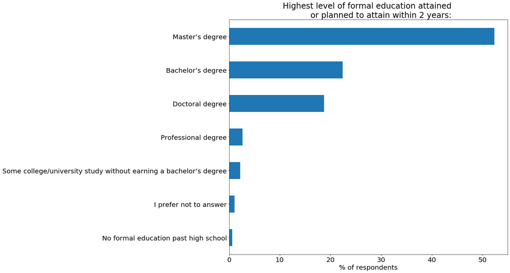

```python
# higest level of education (attained/planned)
plt.figure(figsize = (15,13))
(df['Q4'].value_counts(normalize=True) * 100).plot(kind='barh').invert_yaxis()
plt.title('Highest level of formal education attained \n\
          or planned to attain within 2 years:', fontsize=24)
plt.yticks(fontsize=20)
plt.xticks(fontsize=20)
plt.xlabel('% of respondents', fontsize=20)
plt.show()
```

```python
df['Q4'].value_counts(normalize=True) * 100
```

```
Master’s degree                                                      52.362301
Bachelor’s degree                                                    22.423501
Doctoral degree                                                      18.727050
Professional degree                                                  2.668299
Some college/university study without earning a bachelor’s degree    2.178703
I prefer not to answer                                               1.052632
No formal education past high school                                 0.587515
Name: Q4, dtype: float64
```

**The most common level of education attained or planned to attain within 2 years is a master's degree (52% of respondents). This could give an indication of what kind of education to focus on in becoming a data scientist.**

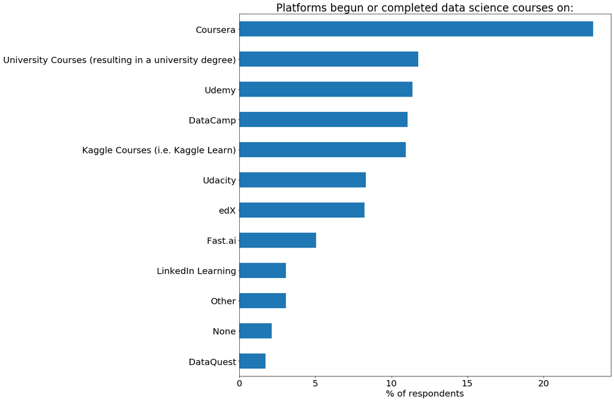

```python
# platforms begun or completed data science courses on
Q13 = (df[['Q13_Part_1',
          'Q13_Part_2',
          'Q13_Part_3',
          'Q13_Part_4',
          'Q13_Part_5',
          'Q13_Part_6',
          'Q13_Part_7',
          'Q13_Part_8',
          'Q13_Part_9',
          'Q13_Part_10',
          'Q13_Part_11',
          'Q13_Part_12']].stack().value_counts(normalize=True) * 100)

plt.figure(figsize = (15,15))
Q13.plot(kind='barh').invert_yaxis()
plt.title('Platforms begun or completed data science courses on:', fontsize=24)
plt.yticks(fontsize=20)
plt.xticks(fontsize=20)
plt.xlabel('% of respondents', fontsize=20)
plt.show()
```

```python
Q13
```

```
Coursera                                                 23.254620
University Courses (resulting in a university degree)    11.765914
Udemy                                                    11.375770
DataCamp                                                 11.067762
Kaggle Courses (i.e. Kaggle Learn)                       10.934292
Udacity                                                  8.326489
edX                                                      8.223819
Fast.ai                                                  5.051335
LinkedIn Learning                                        3.069815
Other                                                    3.059548
None                                                     2.135524
DataQuest                                                1.735113
dtype: float64
```

**The most common learning platform where the respondents have begun or completed data science courses is Coursera (23% of respondents), which can give an indication on where to take courses as an aspiring data scientist.**

## 2. How do different education levels and learning platforms relate to compensation?

```python
def train_models(X_train, y_train):
    '''
    Function that:
    - instantiates and trains regression models on train sets

    INPUT:
    'X_train' - train set
    'y_train' - train set

    OUTPUT:
    trained regression models:
     - 'lr_model': linear regression model
     - 'rr_model': ridge regression model
     - 'er_model': elastic-net regression model
     - 'br_model': baynesian ridge regression model
    '''
    # instantiate and train baseline regression models

    # linear regression
    lr = LinearRegression(normalize=True)
    lr_model = lr.fit(X_train, y_train)

    # ridge regression
    rr = linear_model.Ridge(normalize=True)
    rr_model = rr.fit(X_train, y_train)

    # elastic-net regression
    er = ElasticNet(normalize=True, random_state=4)
    er_model = er.fit(X_train, y_train)

    # baynesian ridge regression
    br = linear_model.BayesianRidge(normalize=True)
    br_model = br.fit(X_train, y_train)

    return lr_model, rr_model, er_model, br_model
```

```python
lr_model, rr_model, er_model, br_model = train_models(X_train, y_train)
```

**I have chosen to instantiate and train a few different linear regression models without any hyperparameter tuning, to get baseline results for each model and see which one performs the best. Only linear models have been selected because we can use the coefficients later on in determining the impact of each input feature on our target variable.**

```python
def baseline_predictions(lr_model, rr_model, er_model, br_model):
    '''
    Function that:
    - makes model predictions on test sets and prints performance metrics mean squared error and r-squared error

    INPUT:
    trained regression models:
     - 'lr_model'
     - 'rr_model'
     - 'er_model'
     - 'br_model'

    OUTPUT:
    none
    '''
    # baseline model predictions
    # create lists with the models and their respective names
    models = [lr_model,
              rr_model,
              er_model,
              br_model]

    model_names = ['linear regression',
                   'ridge regression',
                   'elastic-net regression',
                   'baynesian ridge regression']

    # for all models, make prediction, calculate f1 scores and display results
    for i in range(len(models)):
        model = models[i]
        model_name = model_names[i]
        # predict on train set
        y_train_preds = model.predict(X_train)
        # predict on test set
        y_test_preds = model.predict(X_test)
        # print mean squared error and r-squared score for each model
        print('{}:'.format(model_name))
        print('')
        print('Mean squared error for {} on train set: {}'.format(model_name,
                                                                  mean_squared_error(y_train, y_train_preds)))
        print('R-squared error for {} on train set: {}'.format(model_name,
                                                               r2_score(y_train, y_train_preds)))
        print('')
        print('Mean squared error for {} on test set: {}'.format(model_name,
                                                                 mean_squared_error(y_test, y_test_preds)))
        print('R-squared error for {} on test set: {}'.format(model_name,
                                                              r2_score(y_test, y_test_preds)))
        print('')
```

```python
baseline_predictions(lr_model, rr_model, er_model, br_model)
```

```
linear regression:

Mean squared error for linear regression on train set: 39.34578591051805
R-squared error for linear regression on train set: 0.10654310784961796

Mean squared error for linear regression on test set: 38.543605483058606
R-squared error for linear regression on test set: 0.08947111352696147

ridge regression:

Mean squared error for ridge regression on train set: 40.28107514130878
R-squared error for ridge regression on train set: 0.0853047314881834

Mean squared error for ridge regression on test set: 38.91610564665031
R-squared error for ridge regression on test set: 0.08067141368270947

elastic-net regression:

Mean squared error for elastic-net regression on train set: 44.03769925129815
R-squared error for elastic-net regression on train set: 0.0

Mean squared error for elastic-net regression on test set: 42.34115495310551
R-squared error for elastic-net regression on test set: -0.00023970742381607124

baynesian ridge regression:

Mean squared error for baynesian ridge regression on train set: 39.32094171956097
R-squared error for baynesian ridge regression on train set: 0.10710726518252744

Mean squared error for baynesian ridge regression on test set: 38.40102244410061
R-squared error for baynesian ridge regression on test set: 0.09283940183484762
```

**I have chosen the metrics 'mean squared error' and 'r-squared error' as performance metrics for these regression models. The metric 'mean squared error' is the average of the squared difference between the target value and the value predicted by the regression model, and 'r-squared error' helps us to compare our current model with a constant baseline and tells us how much our model is better.**

**The mean squared error is the lowest (which is preferred) for the baynesian ridge regression model and the r-squared error is the highest (which is preferred) for the same model on the test set. However, none of the models are performing very well at all.**

**Let's see if we can improve the performance of the baynesian ridge regression model by tuning some of its hyperparameters.**

```python
# get model parameters
br_model.get_params
```

```
<bound method BaseEstimator.get_params of BayesianRidge(alpha_1=1e-06, alpha_2=1e-06, compute_score=False, copy_X=True,
              fit_intercept=True, lambda_1=1e-06, lambda_2=1e-06, n_iter=300,
              normalize=True, tol=0.001, verbose=False)>
```

```python
# create parameters dictionary of hyperparameter options to test
parameters = {'n_iter': [50, 100, 200, 300, 400], # default: 300
              'alpha_1': [0.00000001, 0.0000001, 0.000001, 0.00001, 0.0001], # default: 0.000001
              'alpha_2': [0.00000001, 0.0000001, 0.000001, 0.00001, 0.0001], # default: 0.000001
              'lambda_1': [0.00000001, 0.0000001, 0.000001, 0.00001, 0.0001], # default: 0.000001
              'lambda_2': [0.00000001, 0.0000001, 0.000001, 0.00001, 0.0001], # default: 0.000001
              'tol': [0.0001, 0.001, 0.01, 0.1]} # default: 0.001

# create gridsearch object
grid_obj = GridSearchCV(br_model, parameters)

# fit gridsearch object on training data
grid_fit = grid_obj.fit(X_train, y_train)

# store best model
best_model = grid_fit.best_estimator_

# predict on test set
y_test_preds = best_model.predict(X_test)

print('For tuned baynesian ridge regression model:')
print('Mean squared error on test set: {}'.format(mean_squared_error(y_test, y_test_preds)))
print('R-squared error on test set: {}'.format(r2_score(y_test, y_test_preds)))
```

```
For tuned baynesian ridge regression model:
Mean squared error on test set: 38.401021835128354
R-squared error on test set: 0.09283941622080938
```

**We didn't manage to improve the baynesian ridge regression model performance at all by tuning its hyperparameters.**

```python
# get best model parameters
best_model.get_params
```

```
<bound method BaseEstimator.get_params of BayesianRidge(alpha_1=1e-08, alpha_2=0.0001, compute_score=False, copy_X=True,
              fit_intercept=True, lambda_1=0.0001, lambda_2=1e-08, n_iter=50,
              normalize=True, tol=0.1, verbose=False)>
```

**The hyperparameters changed in the tuned baynesian ridge regression model compared to its baseline are:**

- **alpha_1=1e-08 (default is 1e-06)**
- **alpha_2=0.0001 (default is 1e-06)**
- **lambda_1=0.0001 (default is 1e-06)**
- **lambda_2=1e-08 (default is 1e-06)**
- **n_iter=50 (default is 300)**
- **tol=0.1 (default is 0.001)**

```python
def calc_coefs(feature_names, model_coefficients):
    '''
    Function that:
    - creates new dataframe with coefficients per input feature from best tuned model, recodes these into
      new absolute values in new column
    - scales coefficients by using a minmax scaler to be in the range of -1 to 1, merges this column onto
      dataframe and sets feture names as index

    INPUT:
    'feature_names': input feature names
    'model_coefficients': coefficients for model

    OUTPUT:
    coef_df (pandas dataframe)
    '''
    # calculate coefficient estimates per input feature for best model

    # create new dataframe
    coef_df = pd.DataFrame()

    # create column with feature names
    coef_df['est_int'] = feature_names

    # create column with feature coefficients
    coef_df['coefs'] = model_coefficients

    # create column with feature coefficients as absolute values
    coef_df['abs_coefs'] = np.abs(model_coefficients)

    # sort dataframe by 'abs_coefs' in descending order
    coef_df = coef_df.sort_values('abs_coefs', ascending=False)

    # reset index to merge on column with scaled features
    coef_df = coef_df.reset_index(drop=True)

    # normalize coefficient weights before plotting them

    # store 'coefs' as 'x'
    x = coef_df[['coefs']]

    # create minmaxscaler object
    scaler = MinMaxScaler(feature_range=(-1, 1))

    # fit and transform 'x' to minmaxscaler object
    x_scaled = scaler.fit_transform(x)

    # create dataframe of 'x'
    coef_normalized = pd.DataFrame(x_scaled, columns=['scaled_coefs'])

    # merge 'coef_df' and 'coef_normalized' on index of both the dataframes
    coef_df = coef_df.merge(coef_normalized, how='left', left_index=True, right_index=True)

    # set 'est_int' as index
    coef_df = coef_df.set_index('est_int')

    return coef_df
```

```python
coef_df = calc_coefs(X_train.columns, best_model.coef_)
coef_df
```

| est_int | coefs | abs_coefs | scaled_coefs |
| --- | --- | --- | --- |
| Some college/university study without earning a bachelor’s degree | -3.324036 | 3.324036 | -1.000000 |
| Doctoral degree | 2.286431 | 2.286431 | 1.000000 |
| Fast.ai | 2.031001 | 2.031001 | 0.908945 |
| I prefer not to answer | -2.020333 | 2.020333 | -0.535260 |
| Bachelor’s degree | -1.822050 | 1.822050 | -0.464577 |
| None | 1.716843 | 1.716843 | 0.796955 |
| Coursera | 1.358180 | 1.358180 | 0.669100 |
| No formal education past high school | -1.278453 | 1.278453 | -0.270798 |
| Kaggle Courses | -1.203204 | 1.203204 | -0.243973 |
| Professional degree | -1.142920 | 1.142920 | -0.222483 |
| DataQuest | -1.055098 | 1.055098 | -0.191177 |
| Other | -0.852453 | 0.852453 | -0.118939 |
| University Courses | 0.836556 | 0.836556 | 0.483153 |
| edX | 0.756232 | 0.756232 | 0.454520 |
| Udacity | 0.633727 | 0.633727 | 0.410850 |
| Udemy | -0.457143 | 0.457143 | 0.021980 |
| Master’s degree | 0.336769 | 0.336769 | 0.304991 |
| LinkedIn Learning | -0.297332 | 0.297332 | 0.078949 |
| DataCamp | 0.060953 | 0.060953 | 0.206669 |

**I have created a dataframe with the input features and their coefficient weights. We can look at the size of the coefficients ('abs_coefs') in the model as an indication of the impact of each input feature on the target variable, yearly compensation in USD. The larger the coefficient, the larger the expected impact on the compensation.**

**I would like to plot the relative impact of each feature based on their coefficient weights, and to do this I have scaled the coefficients by using a MinMaxScaler with the range of -1 to 1, which is a scaler that represents the original data distribution well.**

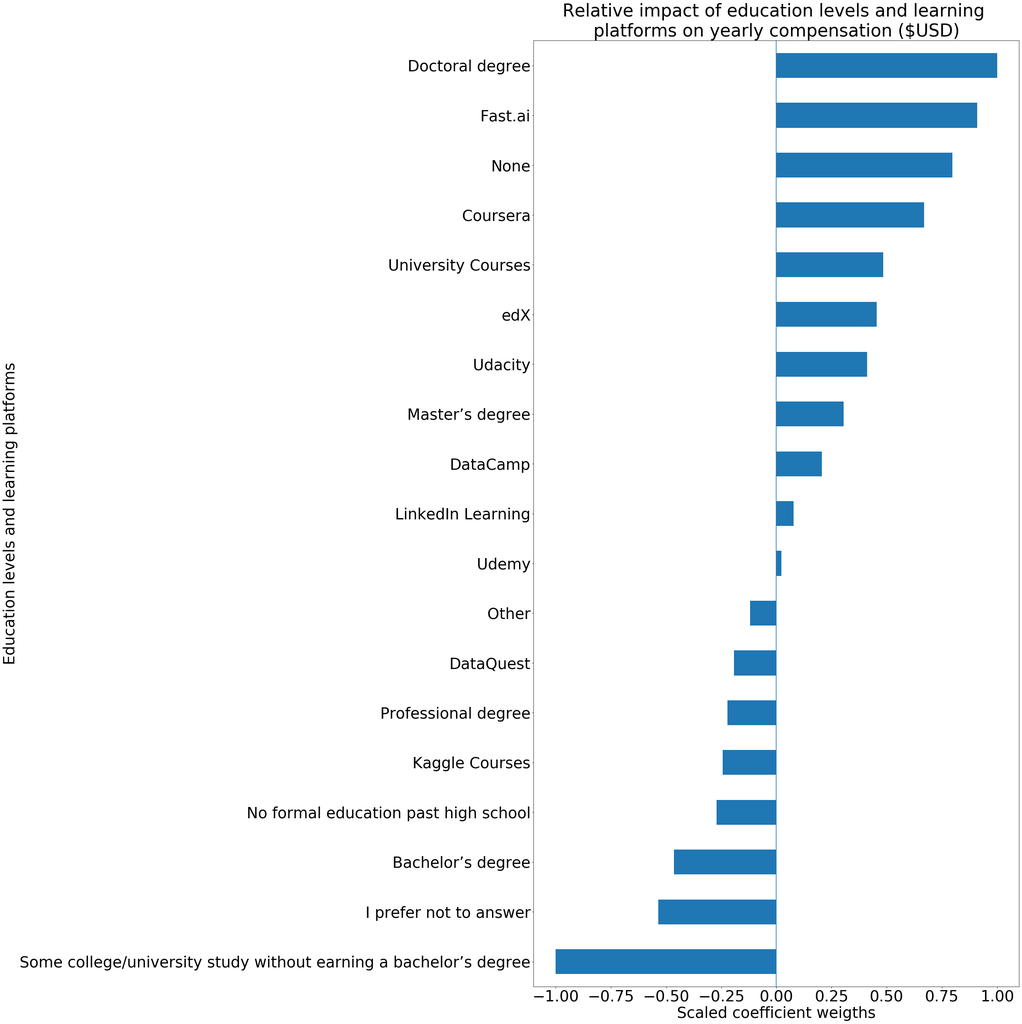

```python
# plot scaled coefficients and their column name

# sort dataframe by 'scaled_coefs' in descending order
coef_sorted = coef_df['scaled_coefs'].sort_values(ascending=False)

plt.figure(figsize = (20,40))
coef_sorted.plot(kind='barh').invert_yaxis()
plt.axvline(x=0)
plt.title('Relative impact of education levels and learning \n\
platforms on yearly compensation ($USD)', fontsize=40)
plt.yticks(fontsize=35)
plt.ylabel('Education levels and learning platforms', fontsize=35)
plt.xticks(fontsize=35)
plt.xlabel('Scaled coefficient weigths', fontsize=35)
plt.show()
```

**Here we can see a plot of the relative impact of the input variables based on their scaled coefficients. Having a doctoral degree appears to have the most positive impact on compensation and having some college/university study without getting a bachelor's degree seems to have the most negative impact on compensation.**

## 3. What programming language should I learn?

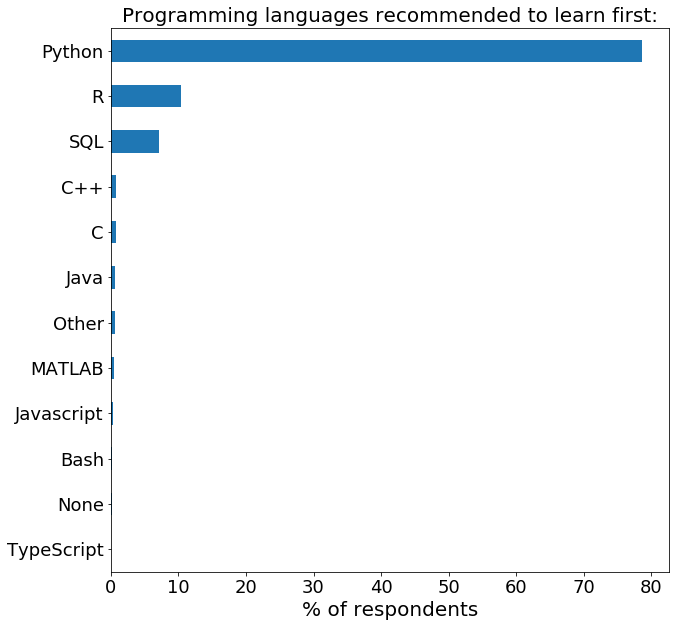

```python
# Plot results for Q19: 'What programming language would you recommend an aspiring data scientist to learn first?'
plt.figure(figsize = (10,10))
(df['Q19'].value_counts(normalize=True) * 100).plot(kind='barh').invert_yaxis()
plt.title('Programming languages recommended to learn first:', fontsize=20)
plt.yticks(fontsize=18)
plt.xticks(fontsize=18)
plt.xlabel('% of respondents', fontsize=20)
plt.show()
```

```python
df['Q19'].value_counts(normalize=True) * 100
```

```
Python        78.678679
R             10.330330
SQL           7.087087
C++           0.750751
C             0.690691
Java          0.660661
Other         0.630631
MATLAB        0.510511
Javascript    0.240240
Bash          0.210210
None          0.150150
TypeScript    0.060060
Name: Q19, dtype: float64
```

**Almost 80% of the respondents recommend aspiring data scientists to learn Python first of all mentioned programming languages.**

## 4. What biases might respondents have in recommending which programming language to learn?

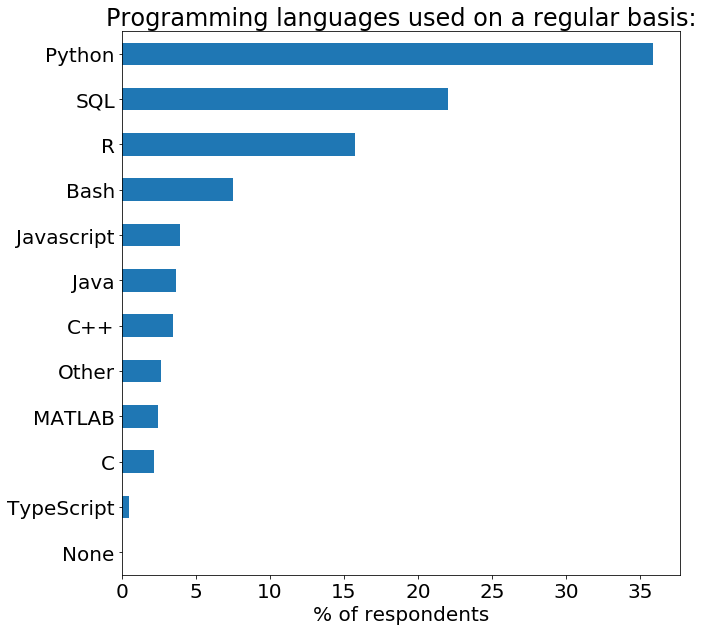

```python
# Plot results for Q18: 'What programming languages do you use on a regular basis?'
Q18 = (df[['Q18_Part_1',
 'Q18_Part_2',
 'Q18_Part_3',
 'Q18_Part_4',
 'Q18_Part_5',
 'Q18_Part_6',
 'Q18_Part_7',
 'Q18_Part_8',
 'Q18_Part_9',
 'Q18_Part_10',
 'Q18_Part_11',
 'Q18_Part_12']].stack().value_counts(normalize=True) * 100)



plt.figure(figsize = (10,10))
Q18.plot(kind='barh').invert_yaxis()
plt.title('Programming languages used on a regular basis:', fontsize=24)
plt.yticks(fontsize=20)
plt.xticks(fontsize=20)
plt.xlabel('% of respondents', fontsize=20)
plt.show()
```

```python
Q18
```

```
Python        35.886866
SQL           22.054277
R             15.733425
Bash          7.477385
Javascript    3.939082
Java          3.629910
C++           3.458147
Other         2.668041
MATLAB        2.461926
C             2.187106
TypeScript    0.492385
None          0.011451
dtype: float64
```

```python
# display dataframe with red and green bars highlighting the difference between 'use_yes' and 'use_no'
df_comp.style.bar(subset=['diff_recommend'], align='mid', color=['#d65f5f', '#5fba7d'])
```

| programming_language | use_yes | use_no | diff_recommend |
| --- | --- | --- | --- |
| Python | 0.975191 | 0.0248092 | 0.950382 |
| R | 0.930233 | 0.0697674 | 0.860465 |
| SQL | 0.902542 | 0.0974576 | 0.805085 |
| C | 0.391304 | 0.608696 | -0.217391 |
| C++ | 0.6 | 0.4 | 0.2 |
| Java | 0.454545 | 0.545455 | -0.0909091 |
| Javascript | 0.625 | 0.375 | 0.25 |
| TypeScript | 0.5 | 0.5 | 0 |
| Bash | 0.714286 | 0.285714 | 0.428571 |
| MATLAB | 0.529412 | 0.470588 | 0.0588235 |
| None | 0.2 | 0.8 | -0.6 |
| Other | 0.52381 | 0.47619 | 0.047619 |

**Above we can see a dataframe with the programming languages and two columns with the percentage of respondents who recommend to learn each programming language and if they use it on a regular basis or not. The last column shows the difference between the group that uses the langage regularly and the group that doesn't. For example, we can see that respondents that use Python regularly recommend learning Python 95% more than respondents who don't. Interestingly, respondents that don't use C regularly recommend it more that respondents who do use it on a regular basis.**

```python
df_comp.sort_values(by=['use_yes'], ascending=False)
```

| programming_language | use_yes | use_no | diff_recommend |
| --- | --- | --- | --- |
| Python | 0.975191 | 0.024809 | 0.950382 |
| R | 0.930233 | 0.069767 | 0.860465 |
| SQL | 0.902542 | 0.097458 | 0.805085 |
| Bash | 0.714286 | 0.285714 | 0.428571 |
| Javascript | 0.625000 | 0.375000 | 0.250000 |
| C++ | 0.600000 | 0.400000 | 0.200000 |
| MATLAB | 0.529412 | 0.470588 | 0.058824 |
| Other | 0.523810 | 0.476190 | 0.047619 |
| TypeScript | 0.500000 | 0.500000 | 0.000000 |
| Java | 0.454545 | 0.545455 | -0.090909 |
| C | 0.391304 | 0.608696 | -0.217391 |
| None | 0.200000 | 0.800000 | -0.600000 |

**The most recommended programming languages by those who use it regularly are Python and R.**

```python
df_comp.sort_values(by=['use_no'], ascending=False)
```

| programming_language | use_yes | use_no | diff_recommend |
| --- | --- | --- | --- |
| None | 0.200000 | 0.800000 | -0.600000 |
| C | 0.391304 | 0.608696 | -0.217391 |
| Java | 0.454545 | 0.545455 | -0.090909 |
| TypeScript | 0.500000 | 0.500000 | 0.000000 |
| Other | 0.523810 | 0.476190 | 0.047619 |
| MATLAB | 0.529412 | 0.470588 | 0.058824 |
| C++ | 0.600000 | 0.400000 | 0.200000 |
| Javascript | 0.625000 | 0.375000 | 0.250000 |
| Bash | 0.714286 | 0.285714 | 0.428571 |
| SQL | 0.902542 | 0.097458 | 0.805085 |
| R | 0.930233 | 0.069767 | 0.860465 |
| Python | 0.975191 | 0.024809 | 0.950382 |

**The most recommended programming languages by those who don't use it are C and Java (after recommending to learn no programming language).**

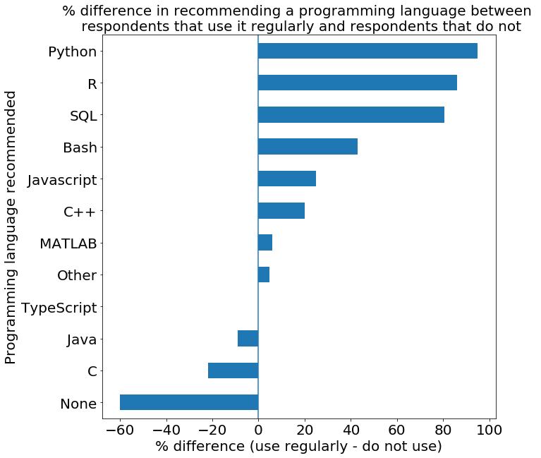

```python
# plot difference per programming language recommended between those who use it regularly and those who don't use it

# sort dataframe by 'diff_recommended' in descending order
comp_sorted = (df_comp['diff_recommend'] * 100).sort_values(ascending=False)

plt.figure(figsize = (10,10))
comp_sorted.plot(kind='barh').invert_yaxis()
plt.axvline(x=0)
plt.title('% difference in recommending a programming language between \n \
respondents that use it regularly and respondents that do not', fontsize=20)
plt.yticks(fontsize=20)
plt.ylabel('Programming language recommended', fontsize=20)
plt.xticks(fontsize=20)
plt.xlabel('% difference (use regularly - do not use)', fontsize=20)
plt.show()
```

**Above is a plot of the percentual difference between those who use a programming language regularly and would recommend learning it, and those who don't use the programming language on a regular basis but recommend learning it first.**

## 5. Evaluate the Results

**I have evaluated the result under each question heading, but overall I would say that the data we have used help to answer the business questions we wanted to explore. We can learn by looking at what kind of education data scientists active in the industry have, what learning platforms they use to improve their data science skills and what level of compensation they have, to understand what kind of education is attractive and what level of compensation it could result in. We also explored what programming language to focus on, by using responses from data scientists directly, of which programming language they would recommend an aspiring data scientist to learn first. Lastly, we saw that there is bias in which programming languages the resondents would recommend to learn, especially for Python and R.**

## 6. Deploy

**A blog post of my findings can be found [here](https://medium.com/@linn.ohlsson/what-should-you-focus-on-as-an-aspiring-data-scientist-cfae11b70d88).**